# Performance Evaluation

Thilo

## Introduction

We investigate the performance of various machine learning models, that are intended to predict market behavior based on planetary locations. To this end, a test is performed that compares the performance of the models against random prediction.

It has been noted, that there are some models, that show a high accuracy (e.g. greater than 70%) over a period of time. The arising question is, whether this is just a product of chance or does the model have indeed predictive power? Even though such a high accuracy seems very unlikely, there is a chance, that due to the large number of considered model, there are some outliers, that just by chance, show a high accuracy for a limited time.

To this end, we compare each model to the corresponding random behavior and determine the p-value. The p-value is the probability, to obtain at least the given accuracy, provided the model just makes random predictions.

The p-values are combined using Fisher’s-Method (https://en.wikipedia.org/wiki/Fisher%27s_method) to get an overall view about the results.

## Assumptions

Null hypothesis: We assume each model makes accurate predictions with a probability, that is estimated from the prevalence and the actual market behaviour. I.e. (prevalence*frequency-market-up-moves + (1-prevalance)*(1-frequency-market-up-moves)). If the result of the study is significant and models indeed perform better than random, a more sophisticated analysis should be performed.

According to the Null-hypothesis the models are described by a binomial distribution. Hence we can use the binomial test with one sided alternative hypothesis to determine p-values.

## Preparation

First we load the performance report.

```r
date <- '2021-02-09'
path <- 'performance/'
filename <- paste0(path, 'models-predict-performance-', date,'.csv')

data <- read_delim(filename, delim=',')
data %>% head(n=5) %>% kable
```

| PredictFile | Symbol | Created | ProdDays | actFrequency | AccProd | correctProdDays | PrevProd | Acc6m | Acc3m | Acc2m | Acc1m | AccSD6m | AccSD3m | AccSD2m | Prev6m | Prev3m | Prev2m | Prev1m | PrevSD6m | PrevSD3m | PrevSD2m | Rank |
| --- | --- | --- | --- | --- | --- | --- | --- | --- | --- | --- | --- | --- | --- | --- | --- | --- | --- | --- | --- | --- | --- | --- |
| ADA-USD-predict-ensamble-gakknn-MC.csv | ADA-USD | 2020-11-16 09:26:41 | 85 | 0.5882353 | 0.6588235 | 56 | 0.4823529 | 0.609 | 0.641 | 0.677 | 0.677 | 0.137 | 0.064 | 0.000 | 0.434 | 0.522 | 0.516 | 0.742 | 0.193 | 0.226 | 0.319 | 0.6400688 |
| ADA-USD-predict-ensamble-gakknn-PABB.csv | ADA-USD | 2020-12-03 13:52:23 | 64 | 0.5937500 | 0.6250000 | 40 | 0.4375000 | 0.632 | 0.668 | 0.640 | 0.667 | 0.137 | 0.056 | 0.038 | 0.520 | 0.454 | 0.422 | 0.296 | 0.083 | 0.137 | 0.178 | 0.6200095 |
| ADA-USD-predict-ensamble-gakknn-VDIA.csv | ADA-USD | 2020-12-24 21:05:29 | 47 | 0.6595745 | 0.6808511 | 32 | 0.4680851 | 0.599 | 0.642 | 0.629 | 0.677 | 0.140 | 0.053 | 0.068 | 0.503 | 0.391 | 0.403 | 0.419 | 0.135 | 0.027 | 0.023 | 0.6024841 |
| ADA-USD-predict-ensamble-gakknn-MIHA.csv | ADA-USD | 2020-11-28 20:13:54 | 73 | 0.5890411 | 0.6301370 | 46 | 0.5753425 | 0.562 | 0.608 | 0.645 | 0.677 | 0.153 | 0.072 | 0.046 | 0.494 | 0.509 | 0.581 | 0.548 | 0.120 | 0.128 | 0.046 | 0.5985294 |
| ADA-USD-predict-ensamble-gakknn-MIHDB.csv | ADA-USD | 2020-11-29 12:56:40 | 72 | 0.5833333 | 0.6388889 | 46 | 0.5833333 | 0.640 | 0.620 | 0.613 | 0.645 | 0.115 | 0.034 | 0.046 | 0.530 | 0.566 | 0.548 | 0.516 | 0.173 | 0.044 | 0.046 | 0.5950554 |

```r
binom_test_pvalue = function(x,n) {
    p <- actualFrequency
    test <- binom.test(x, n, p, alternative='two.sided')
    test$p.value
}
probs = c()
pvalues = c()
for (row in 1:nrow(data)) {
  correctDays <- data[row, 'correctProdDays'][[1,1]]
  prodDays <- data[row, 'ProdDays'][[1,1]]
  actFrequency <- data[row, 'actFrequency'][[1,1]]
  prevalence <- data[row, 'PrevProd'][[1,1]]
  p = actFrequency*prevalence + (1-actFrequency)*(1-prevalence)
  test <- binom.test(correctDays, prodDays, p, alternative='greater')
  pvalue <- test$p.value
  probs = c(probs, p)
  pvalues <- c(pvalues, pvalue)
}
data$prob = probs
data$pvalue = pvalues
data %>% select(PredictFile, Created, ProdDays, actFrequency, PrevProd, AccProd, correctProdDays, prob, pvalue) %>%
  head(n=10) %>% kable
```

| PredictFile | Created | ProdDays | actFrequency | PrevProd | AccProd | correctProdDays | prob | pvalue |
| --- | --- | --- | --- | --- | --- | --- | --- | --- |
| ADA-USD-predict-ensamble-gakknn-MC.csv | 2020-11-16 09:26:41 | 85 | 0.5882353 | 0.4823529 | 0.6588235 | 56 | 0.4968858 | 0.0018830 |
| ADA-USD-predict-ensamble-gakknn-PABB.csv | 2020-12-03 13:52:23 | 64 | 0.5937500 | 0.4375000 | 0.6250000 | 40 | 0.4882812 | 0.0192869 |
| ADA-USD-predict-ensamble-gakknn-VDIA.csv | 2020-12-24 21:05:29 | 47 | 0.6595745 | 0.4680851 | 0.6808511 | 32 | 0.4898144 | 0.0063497 |
| ADA-USD-predict-ensamble-gakknn-MIHA.csv | 2020-11-28 20:13:54 | 73 | 0.5890411 | 0.5753425 | 0.6301370 | 46 | 0.5134172 | 0.0296228 |
| ADA-USD-predict-ensamble-gakknn-MIHDB.csv | 2020-11-29 12:56:40 | 72 | 0.5833333 | 0.5833333 | 0.6388889 | 46 | 0.5138889 | 0.0219640 |
| ADA-USD-predict-ensamble-gakknn-QBB.csv | 2020-12-04 08:16:36 | 64 | 0.5781250 | 0.7187500 | 0.6406250 | 41 | 0.5341797 | 0.0559872 |
| ADA-USD-predict-ensamble-gakknn-MAA.csv | 2020-11-14 19:40:50 | 84 | 0.6071429 | 0.6071429 | 0.6428571 | 54 | 0.5229592 | 0.0176964 |
| ADA-USD-predict-ensamble-gakknn-VBA.csv | 2020-12-06 17:50:18 | 65 | 0.6000000 | 0.4769231 | 0.6000000 | 39 | 0.4953846 | 0.0587636 |
| ADA-USD-predict-ensamble-gakknn-PCB.csv | 2020-12-03 11:57:43 | 66 | 0.5757576 | 0.5909091 | 0.5606061 | 37 | 0.5137741 | 0.2620931 |
| ADA-USD-predict-ensamble-gakknn-UAB.csv | 2020-12-05 20:44:41 | 58 | 0.5689655 | 0.3965517 | 0.5517241 | 32 | 0.4857313 | 0.1910046 |

We combine the p-values according to Fisher’s method.

```r
confidence_level <- 0.95

test <- sumlog(pvalues)
cat(paste0('The p-value is: ', test$p))
```

The p-value is: 1

```r
cat('\n\n')
```

```r
if(test$p < 1-confidence_level) {
  cat('**We have to reject the hypothesis that the results are random.**')
} else {
  cat('**We cannot reject the hypothesis that the results are random.**')
}
```

**We cannot reject the hypothesis that the results are random.**

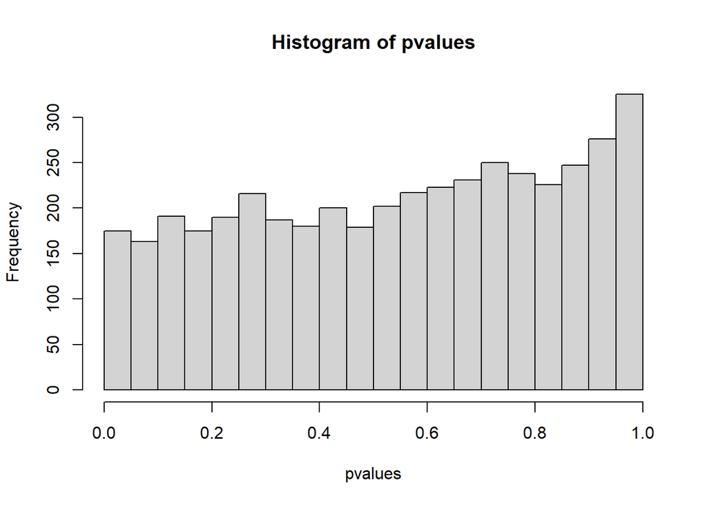

```r
hist(pvalues, breaks=30)
```

The probability to predict the correct outcome under the assumption of indepencence is:

P(Buy)*P(PredictBuy) + P(Sell)*P(PredictSell)

i.e.

actualFrequency*prevalence + (1-actualFrequency)*(1-prevalence).

The following histogram shows the distribution of probabilities.

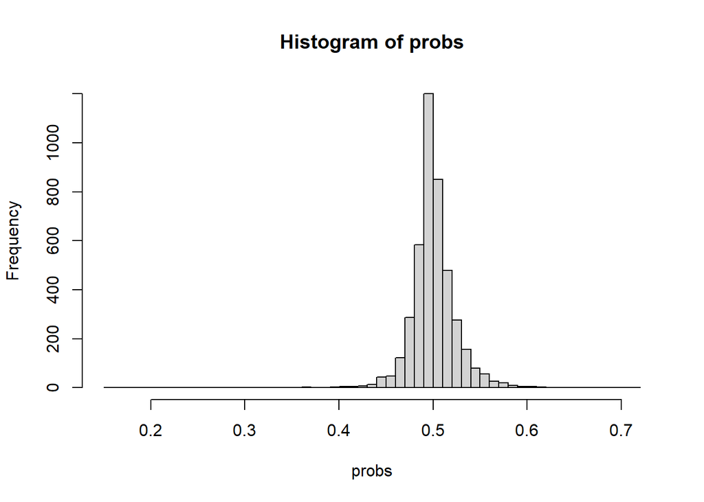

```r
hist(probs, breaks=50)
```

## Interpretation

As of 2021-02-09: The outcome of the models cannot be distinguished statistically from random behaviour. The probability of predicting the correct outcome is around 0.5 for most of the models.